# Partiel 2019 _ Matisse Landais

# Exercice 2 : étude statistique globale

```r
groupe1 <- c(15.3,9.3,13.3,14.0,7.3,7.3,16.0,16.7,13.3,12.7,14.7,12.0,9.3,11.3,8.7,16.0,8.7,11.3,12.0,12.0,16.0,16.7,14.7,9.3,8.7,12.0,14.7,17.3,13.3,15.3)
groupe2 <- c(10.0,12.0,13.3,13.3,12.7,7.3,14.7,8.7,11.3,15.3,14.7,12.0,18.0,10.7,14.0,12.7,10.0,15.3,16.7,10.7,16.0,13.3,7.3,14.7,7.3,11.3,13.3,12.0,14.0,14.7)
groupe3 <- c(7.3,11.3,4.0,10.7,10.0,11.7,17.3,7.3,13.7,11.3,13.3,10.0,16.0,11.7,8.7,8.7,12.0,13.3,10.0,9.0,14.0,8.0,12.0,9.3,11.7,16.0,14.7,14.0,8.7,12.7)
```

## A : calcul des moyenne, estimation générale

```r
cat("Moyenne du groupe 1 : ", mean(groupe1), " et variance : ", sd(groupe1))
```

```
## Moyenne du groupe 1 :  12.64  et variance :  2.999379
```

```r
cat("Moyenne du groupe 2 : ", mean(groupe2), " et variance : ", sd(groupe2))
```

```
## Moyenne du groupe 2 :  12.57667  et variance :  2.75627
```

```r
cat("Moyenne du groupe 3 : ", mean(groupe3), " et variance : ", sd(groupe3))
```

```
## Moyenne du groupe 3 :  11.28  et variance :  2.963386
```

On peut maintenant estimer la loi que pourrait suivre ces notes grâce à un graphe de probabilité et un histogramme.

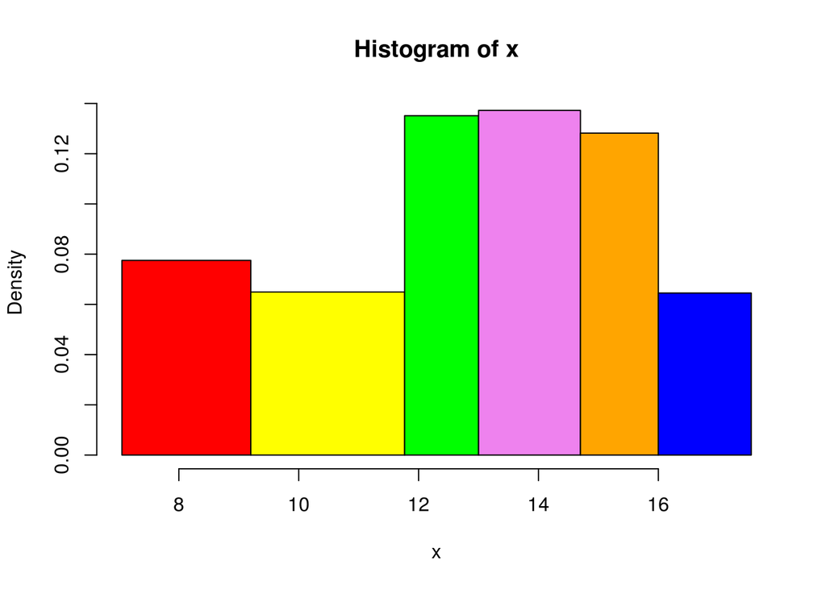

```r
histoeff <- function(x, xlim=NULL, ...)
{
  sx <- sort(x)
  n <- length(x)
  k <- round(log(n)/log(2)+1)
  rangex <- max(x)-min(x)
  quantileVoulu <- quantile(x, seq(1,k-1)/k, max(x))

  breaks <- c(min(x)-0.025*rangex, quantileVoulu, max(x)+0.025*rangex)
  col <- 0
  if (is.null(xlim)) xlim<-c(breaks[1], breaks[k+1])
  colors = c("red", "yellow", "green", "violet", "orange", "blue", "pink", "cyan")

  hist(x, breaks=breaks, col=colors, xlim=xlim, probability=T)
}

histoeff(groupe1)
```

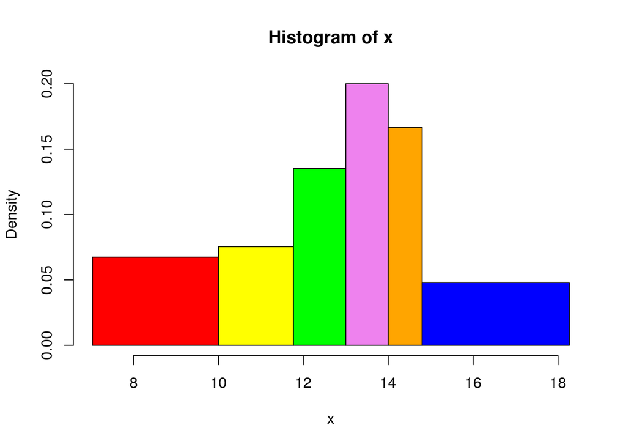

```r
histoeff(groupe2)
```

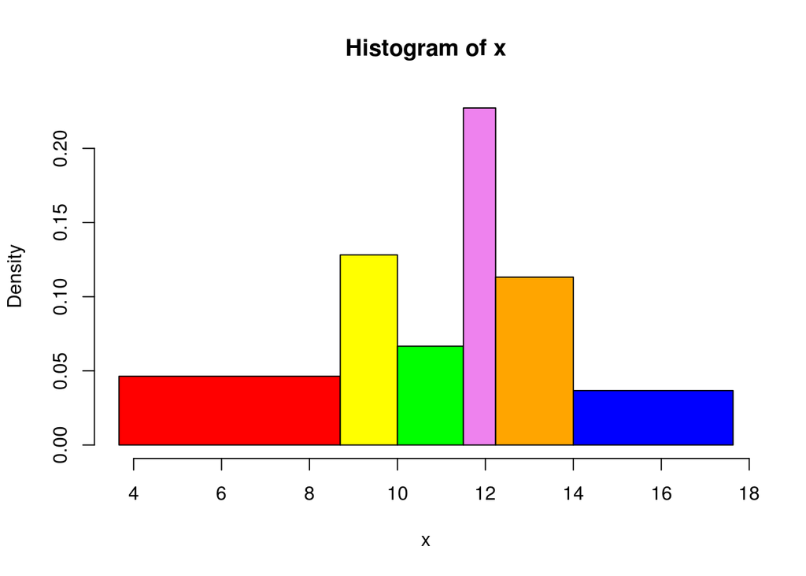

```r
histoeff(groupe3)
```

Cela ressemble à une loi normale. Pour être sur, on peut tracer le graphe de probabilité pour la loi normale avec les 3 groupes.

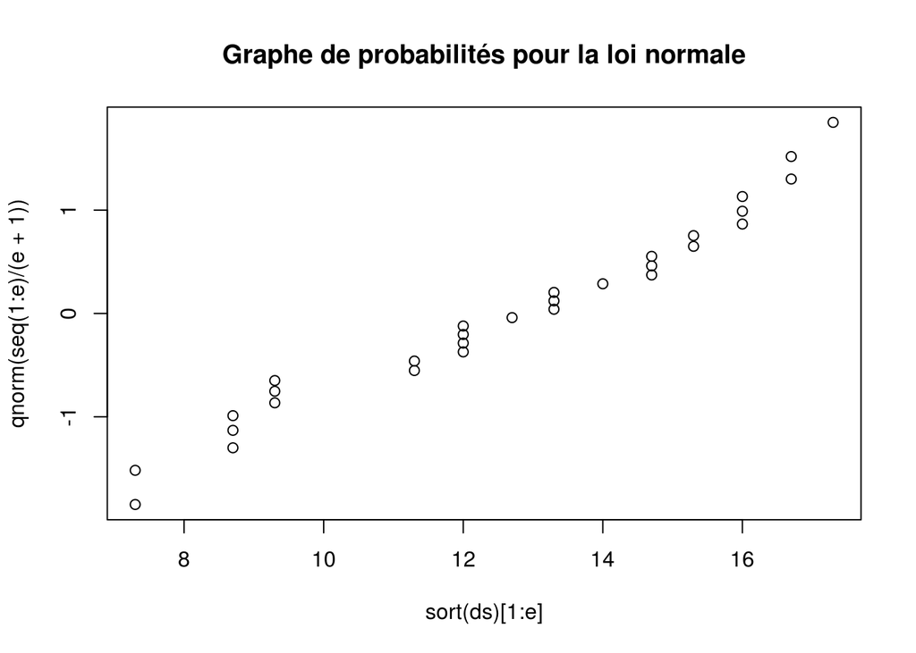

```r
qqplotNormale <- function(ds)
{
  e = length(ds)
  plot(sort(ds)[1:e], qnorm(seq(1:e)/(e+1)), main="Graphe de probabilités pour la loi normale")
}
qqplotNormale(groupe1)
```

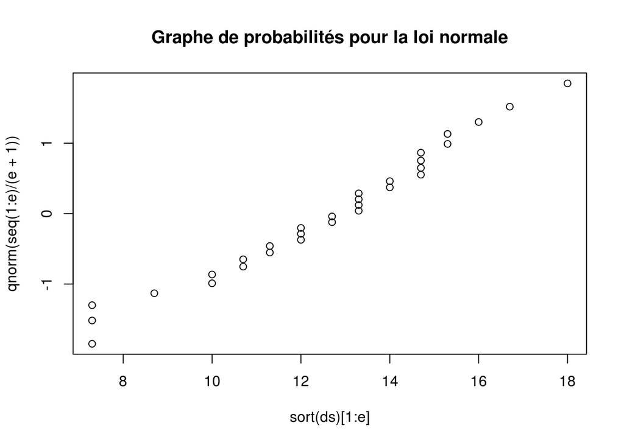

```r
qqplotNormale(groupe2)
```

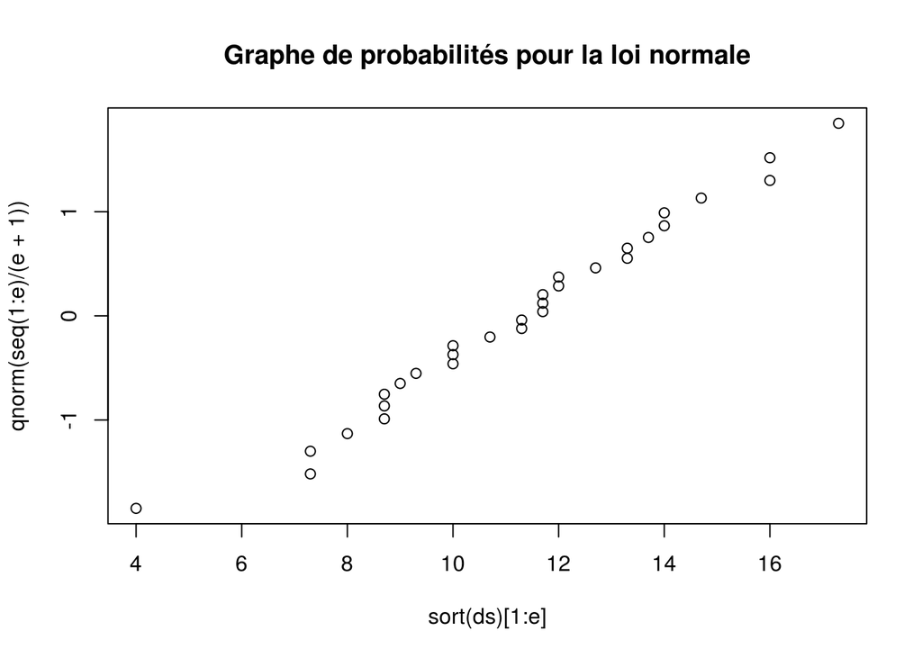

```r
qqplotNormale(groupe3)
```

Les graphes de probabilités sont très semblables à une loi normale (voir les démonstrations sur les graphes de probabilités)

```r
dnorm(10,mean(groupe1), sd(groupe1))
```

```
## [1] 0.0902922
```

```r
dnorm(10,mean(groupe2), sd(groupe2))
```

```
## [1] 0.09350147
```

```r
dnorm(10,mean(groupe3), sd(groupe3))
```

```
## [1] 0.1226333
```

## Intervalles de confiances pour les groupes

Précédemment, nous avons pu voir que les notes des groupes semblaient suivre des lois normales. Bien que la moyenne et l’écart type soient des indicateurs intéressants pour connaître l’étendu des notes, on peut réaliser des intervalles de confiance sur la moyenne. On aurait aussi pour le faire sur la variance. Les intervalles de confiance sont intéressants ici car ils permettent, dans notre cas, de savoir si dans le cas où nous aurions beaucoup plus de groupes de TD, si il n’y aurait pas un déséquilibre en moyenne dans la notation.

### Simulations

On peut donc faire des intervalles de confiance au seuil 20% et 10% pour savoir si un maximum d’élèves valideront la matière ou non.

```r
# à 20%
t.test(groupe1, conf.level=0.80)
```

```
##
##  One Sample t-test
##
## data:  groupe1
## t = 23.082, df = 29, p-value < 2.2e-16
## alternative hypothesis: true mean is not equal to 0
## 80 percent confidence interval:
##  11.92185 13.35815
## sample estimates:
## mean of x
##     12.64
```

```r
t.test(groupe2, conf.level=0.80)
```

```
##
##  One Sample t-test
##
## data:  groupe2
## t = 24.992, df = 29, p-value < 2.2e-16
## alternative hypothesis: true mean is not equal to 0
## 80 percent confidence interval:
##  11.91672 13.23661
## sample estimates:
## mean of x
##  12.57667
```

```r
t.test(groupe3, conf.level=0.80)
```

```
##
##  One Sample t-test
##
## data:  groupe3
## t = 20.849, df = 29, p-value < 2.2e-16
## alternative hypothesis: true mean is not equal to 0
## 80 percent confidence interval:
##  10.57046 11.98954
## sample estimates:
## mean of x
##     11.28
```

```r
# à 10%
t.test(groupe1, conf.level=0.90)
```

```
##
##  One Sample t-test
##
## data:  groupe1
## t = 23.082, df = 29, p-value < 2.2e-16
## alternative hypothesis: true mean is not equal to 0
## 90 percent confidence interval:
##  11.70954 13.57046
## sample estimates:
## mean of x
##     12.64
```

```r
t.test(groupe2, conf.level=0.90)
```

```
##
##  One Sample t-test
##
## data:  groupe2
## t = 24.992, df = 29, p-value < 2.2e-16
## alternative hypothesis: true mean is not equal to 0
## 90 percent confidence interval:
##  11.72163 13.43171
## sample estimates:
## mean of x
##  12.57667
```

```r
t.test(groupe3, conf.level=0.90)
```

```
##
##  One Sample t-test
##
## data:  groupe3
## t = 20.849, df = 29, p-value < 2.2e-16
## alternative hypothesis: true mean is not equal to 0
## 90 percent confidence interval:
##  10.36071 12.19929
## sample estimates:
## mean of x
##     11.28
```

### Conclusion

Imaginons maintenant que l’on réhausse les notes du groupe 3. Ajouter 1 à chaque étudiant revient à ajouter 1 à la moyenne. On peut ensuite refaire l’intervalle de confiance pour le groupe 3 et conclure.

```r
groupe3 <- groupe3 + 1
t.test(groupe3, conf.level=0.9)
```

```
##
##  One Sample t-test
##
## data:  groupe3
## t = 22.697, df = 29, p-value < 2.2e-16
## alternative hypothesis: true mean is not equal to 0
## 90 percent confidence interval:
##  11.36071 13.19929
## sample estimates:
## mean of x
##     12.28
```

En ajoutant 1 à chaque élève du groupe 3, on obtient des moyennes et intervalles de confiance similaire. Un outil plus puissant pour décider s’il faut ajuster ou pas les notes est le test d’hypothèses. Ici, ce serait un test composite avec >10 ou <= 10 (la note)

## Cosa Nostra … et le problème du dé

Le test du KhiDeux est un test d’adéquation. Il permet de savoir si au vu des résultats (ici les occurences / valeur du dé), les observations appartiennent ou non à une certaine loi. Ici, si le dé est équilibré, la loi que l’on veux tester (savoir si les données la suivent), est une loi uniforme. Donc l’hypothèse nulle est H0 : le dé est équilibré car cela correspond à la loi uniforme.

**Le risque le plus important serai de décider H0 (càd le dé est équilibré => Don Pasquale ne meurt pas) alors que la vérité serait H1 ! (Don Pasquale est un tricheur).**

- H0 : le dé est équilibré
- H1 : le dé n’est pas équilibré

| Décision/Vérité | H0 | H1 |
| --- | --- | --- |
| H0 | $1-\alpha$ | $1- \beta$ |
| H1 | $\alpha$ | $\beta$ |